# CMP-3005A Coursework 2

## Question 1:

```python
import numpy as np
import matplotlib.pyplot as plt
```

```
Company 1: Blue
Company 2: Purple
Company 3: Yellow
```

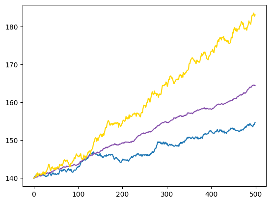

```python
'Setting the random seed'
ran_seed = 99
np.random.seed(ran_seed)

'Setting the number of days'
no_days = 500

"Company 1's Variables"
mu = 0.014 / 100.0
sigma = 0.14 / 100.0
P1 = np.zeros(no_days)
P1[0] = 140

Z1 = np.random.normal(mu, sigma, no_days)
R1 = Z1 + 1

"Company 2's Variables"
mu = 0.028/ 100.0
sigma = 0.06 / 100.0
P2 = np.zeros(no_days)
P2[0] = 140

Z2 = np.random.normal(mu, sigma, no_days)
R2 = Z2 + 1

"Company 3's Variables"
mu = 0.042 / 100.0
sigma = 0.24 / 100.0
P3 = np.zeros(no_days)
P3[0] = 140

Z3 = np.random.normal(mu, sigma, no_days)
R3 = Z3 + 1

'Doing all three companies in the same for loop to save time'
for i in range(1, no_days):
    P1[i] = P1[i-1] * R1[i-1]
    P2[i] = P2[i-1] * R2[i-1]
    P3[i] = P3[i-1] * R3[i-1]

plt.plot(P1)
plt.plot(P2, '#8650AC')
plt.plot(P3, '#FFD700')

'Decalring which company is which to save confusion'
print("Company 1: Blue")
print("Company 2: Purple")
print("Company 3: Yellow")
```

## Question 2A:

```python
'Resetting the random seed'
ran_seed = 99
np.random.seed(ran_seed)

'Declaring the number of days and number of simulations'
no_days = 500
no_simulations = 10000

'Declaring the variables'
mu = 0.042 / 100.0
sigma = 0.084 / 100.0
X = 175
P = np.zeros(no_days)
P[0] = 140

'An array for the payoffs of each simulation'
pi = np.zeros(no_simulations)

for n in range(0, no_simulations-1):
    Z = np.random.normal(mu, sigma, no_days)
    R = Z + 1
    for i in range(1, no_days):
        P[i] = P[i-1] * R[i-1]
    pi[n] = max(X-P[-1], 0)
print("The mean payoff of all the simulations is " + str(np.round_(np.mean(pi), 2)))
```

```
The mean payoff of all the simulations is 0.45
```

## Question 2B:

```python
'Resetting the random seed'
ran_seed = 99
np.random.seed(ran_seed)

'Declaring the number of days and number of simulations'
no_days = 500
no_simulations = 10000

'Declaring the variables'
mu = 0.042 / 100.0
X = 175
P = np.zeros(no_days)
P[0] = 140

'Changing the sigma value to 0.168%'
sigma = 0.168 / 100.0

'An array for the payoffs of each simulation'
pi = np.zeros(no_simulations)

for n in range(0, no_simulations-1):
    Z = np.random.normal(mu, sigma, no_days)
    R = Z + 1
    for i in range(1, no_days):
        P[i] = P[i-1] * R[i-1]
    pi[n] = max(X-P[-1], 0)
print("The mean payoff of all the simulations when sigma is equal to 0.168% is " + str(np.round_(np.mean(pi), 2)))
```

```
The mean payoff of all the simulations when sigma is equal to 0.168% is 3.94
```

## Question 2C:

I couldn't workout the value of μ

## Question 3A:

```python
'Resetting the random seed'
ran_seed = 99
np.random.seed(ran_seed)

'Declaring the number of days and number of simulations'
no_days = 1000
no_simulations = 10000

'Declaring the variables'
mu = 0.042 / 100.0
sigma = 0.084 / 100.0
X = 175
P = np.zeros(no_days)
P[0] = 140
'An array for the payoffs of each simulation'
pi = np.zeros(no_simulations)

for n in range(0, no_simulations-1):
    Z = np.random.normal(mu, sigma, no_days)
    R = Z + 1
    for i in range(1, no_days):
        P[i] = P[i-1] * R[i-1]
    'Takes the sum of the 1000 days and times by 1/1000'
    Pt = (1/1000) * np.sum(P)
    pi[n] = max(X-Pt, 0)
print("The mean payoff of all the simulations is " + str(np.round_(np.mean(pi), 2)))
```

```
The mean payoff of all the simulations is 1.71
```

## Question 3B:

```python
'Resetting the random seed'
ran_seed = 99
np.random.seed(ran_seed)

'Declaring the number of days and number of simulations'
no_days = 1000
no_simulations = 10000

'Declaring the variables'
mu = 0.042 / 100.0
X = 175
P = np.zeros(no_days)
P[0] = 140

'Changing the sigma value to 0.168%'
sigma = 0.168 / 100.0

'An array for the payoffs of each simulation'
pi = np.zeros(no_simulations)

for n in range(0, no_simulations-1):
    Z = np.random.normal(mu, sigma, no_days)
    R = Z + 1
    for i in range(1, no_days):
        P[i] = P[i-1] * R[i-1]
    'Takes the sum of the 1000 days and times by 1/1000'
    Pt = (1/1000) * np.sum(P)
    pi[n] = max(X-Pt, 0)
print("The mean payoff of all the simulations is " + str(np.round_(np.mean(pi), 2)))
```

```
The mean payoff of all the simulations is 2.78
```

## Question 3C:

I couldn't workout the value of μ

## Question 4

```python
class Call:
    def __init__(self, P_0, X, mu, sigma, T, seed):
        ### Create an instance of the Call class with its own data
        self.P_0 = P_0
        self.X = X
        self.mu = mu
        self.sigma = sigma
        self.T = T
        self.seed = seed

    def monte_carlo(self):
        #### Create a simualted price path based on the instance's data
        self.P = np.zeros(self.T)
        self.P[0] = self.P_0

        # Set random number seed
        np.random.seed(self.seed)

        # Generate random numbers
        self.Z = np.random.normal(self.mu, self.sigma, self.T)

        # Convert random numbers to multipliers
        self.R = self.Z + 1

        # Use a For loop to fill in prices
        for i in range(1, self.T):
            self.P[i] = self.P[i-1] * self.R[i-1]

    def plot_path(self):
        ### Quick plot of the price path

        self.x_values = np.linspace(0, self.T  - 1, self.T)
        plt.plot(self.x_values, self.P)

    def compute_payout(self):
        # Payout max(0, P[-1] - X)
        self.payout = max(0, self.P[-1] - self.X)

        print('The price path finished with a price of ' + str(self.P[-1]))
        print('The payout is ' + str(self.payout))
```

```python
call_baseline = Call(P_0=140, X=175, mu=0.00042, sigma=0.00084, T=500, seed=99)

call_mu_test = Call(P_0=140, X=175, mu=0.00084, sigma=0.00168, T=500, seed=99)

call_payout_test = Call(P_0=140, X=150, mu=0.00042, sigma=0.00084, T=500, seed=99)

call_sigma_test = Call(P_0=140, X=175, mu=0.00042, sigma=0.00168, T=500, seed=99)
```

```python
call_baseline.monte_carlo()
call_baseline.compute_payout()
```

```
The price path finished with a price of 175.79805566922195
The payout is 0.7980556692219523
```

```python
call_mu_test.monte_carlo()
call_mu_test.compute_payout()
```

```
The price path finished with a price of 220.65206837788142
The payout is 45.65206837788142
```

```python
call_payout_test.monte_carlo()
call_payout_test.compute_payout()
```

```
The price path finished with a price of 175.79805566922195
The payout is 25.798055669221952
```

```python
call_sigma_test.monte_carlo()
call_sigma_test.compute_payout()
```

```
The price path finished with a price of 178.9584884815522
The payout is 3.9584884815521946
```

So with the values above, we can determine how each variable effects the product.

- The payout threshold test:

With the results of the payout threshold test in comparison to the base results, we can see the amount the business' stock does not increase. However, this makes perfect sense, as all the payout threshold affects is the final calculation, as we decreased the value, the amount the gambler wins is alot more.

- The 𝜎 test:

With the results of the 𝜎 test in comparison to the base results, we can see the amount the business' stock increased only slightly. Because 𝜎 only effects the spread of results from a normal distribution, the amount being only a small increase makes sense, as the general trend; μ, still means the stock increases, but the discrepancy compared with the base data is caused by the increased 𝜎.